# Time Series Forecasting

References: Data Mining for Business Analytics, Shmueli, et al. EMC Code and references have been derived from the above books.

```r
#install.packages("forecast")
```

```r
Amtrak.data <- read.csv("Amtrak.csv")
Amtrak.data
```

| Ridership..In.Thousands. | Month |
| --- | --- |
| 1708.917 | 01/1991 |
| 1620.586 | 02/1991 |
| 1972.715 | 03/1991 |
| 1811.665 | 04/1991 |
| 1974.964 | 05/1991 |
| 1862.356 | 06/1991 |
| 1939.860 | 07/1991 |
| 2013.264 | 08/1991 |
| 1595.657 | 09/1991 |
| 1724.924 | 10/1991 |

[output cut: 149 more lines]

# create time series object using ts()

# ts() takes three arguments: start, end, and freq.

# with monthly data, the frequency of periods per season is 12 (per year).

# arguments start and end are (season number, period number) pairs.

# here start is Jan 1991: start = c(1991, 1); end is Mar 2004: end = c(2004, 3).

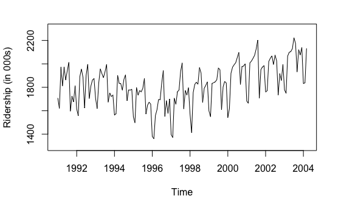

```r
ridership.ts <- ts(Amtrak.data$Ridership,
    start = c(1991, 1), end = c(2004, 3), freq = 12)
plot(ridership.ts, xlab = "Time", ylab = "Ridership (in 000s)", ylim = c(1300, 2300))
```

# use window() to create a new, shorter time series of ridership.ts

# for the new three-year series, start time is Jan 1997 and end time is Dec 1999

```r
ridership.ts.3yrs <- window(ridership.ts, start = c(1997, 1), end = c(1999, 12))
```

# fit a linear regression model to the time series

```r
library(forecast)
ridership.lm <- tslm(ridership.ts ~ trend + I(trend^2))
```

# shorter and longer time series

```r
par(mfrow = c(2, 1))
plot(ridership.ts.3yrs, xlab = "Time", ylab = "Ridership (in 000s)",
                        ylim = c(1300, 2300))
plot(ridership.ts, xlab = "Time", ylab = "Ridership (in 000s)", ylim = c(1300, 2300))
```

[figure not shown]

```r
# overlay the fitted values of the linear model
lines(ridership.lm$fitted, lwd = 1)
```

Now we do Naive forecasts First split the data into training and validation

```r
nValid <- 36
nTrain <- length(ridership.ts) - nValid
# partition the data
train.ts <- window(ridership.ts, start = c(1991, 1), end = c(1991, nTrain))
valid.ts <- window(ridership.ts, start = c(1991, nTrain + 1),
                   end = c(1991, nTrain + nValid))
```

```r
#  generate the naive and seasonal naive forecasts
naive.pred <- forecast::naive(train.ts, h = nValid)
snaive.pred <- forecast::snaive(train.ts, h = nValid)
```

```r
# plot forecasts and actuals in the training and validation sets
plot(train.ts, ylim = c(1300, 2600),  ylab = "Ridership", xlab = "Time", bty = "l",
    xaxt = "n", xlim = c(1991,2006.25), main = "")
axis(1, at = seq(1991, 2006, 1), labels = format(seq(1991, 2006, 1)))
```

```r
lines(naive.pred$mean, lwd = 2, col = "blue", lty = 1)
lines(snaive.pred$mean, lwd = 2, col = "red", lty = 1)
```

```r
lines(valid.ts, col = "grey20", lty = 3)
lines(c(2004.25 - 3, 2004.25 - 3), c(0, 3500))
```

```r
lines(c(2004.25, 2004.25), c(0, 3500))
text(1996.25, 2500, "Training")
```

```r
text(2002.75, 2500, "Validation")
text(2005.25, 2500, "Future")
```

```r
arrows(2004 - 3, 2450, 1991.25, 2450, code = 3, length = 0.1, lwd = 1,angle = 30)
arrows(2004.5 - 3, 2450, 2004, 2450, code = 3, length = 0.1, lwd = 1,angle = 30)
```

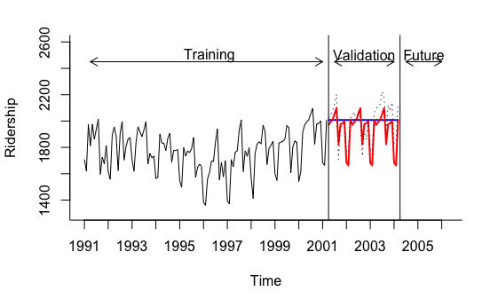

```r
arrows(2004.5, 2450, 2006, 2450, code = 3, length = 0.1, lwd = 1, angle = 30)
```

```r
forecast::accuracy(naive.pred, valid.ts)
```

```
                    ME     RMSE      MAE        MPE     MAPE     MASE
Training set   2.45091 168.1470 125.2975 -0.3460027 7.271393 1.518906
Test set     -14.71772 142.7551 115.9234 -1.2749992 6.021396 1.405269
                   ACF1 Theil's U
Training set -0.2472621        NA
Test set      0.2764480 0.8346967
```

```r
forecast::accuracy(snaive.pred, valid.ts)
```

```
                   ME     RMSE      MAE       MPE     MAPE     MASE
Training set 13.93991 99.26557 82.49196 0.5850656 4.715251 1.000000
Test set     54.72961 95.62433 84.09406 2.6527928 4.247656 1.019421
                  ACF1 Theil's U
Training set 0.6400044        NA
Test set     0.6373346 0.5532435
```

Now, let us model the time series using regression models Linear Trend

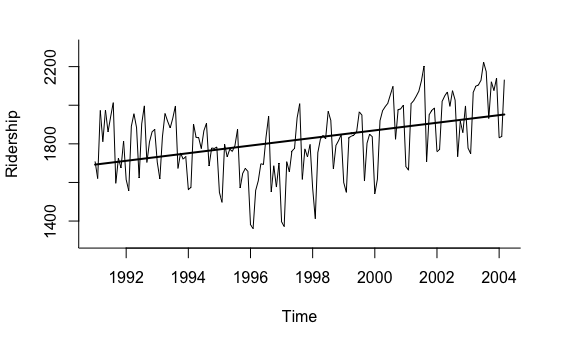

```r
library(forecast)
#Amtrak.data <- read.csv("Amtrak.csv")
# create time series
ridership.ts <- ts(Amtrak.data$Ridership, start = c(1991,1),
                   end = c(2004,3), freq = 12)
# produce linear trend model
ridership.lm <- tslm(ridership.ts ~ trend)
# plot the series
plot(ridership.ts, xlab = "Time", ylab = "Ridership", ylim = c(1300,2300),
     bty = "l")
lines(ridership.lm$fitted, lwd = 2)
```

Now, run the model using validation and training sets

```r
# fit linear trend model to training set and create forecasts
train.lm <- tslm(train.ts ~ trend)
train.lm.pred <- forecast(train.lm, h = nValid, level = 0)
par(mfrow = c(2, 1))
plot(train.lm.pred, ylim = c(1300, 2600),  ylab = "Ridership", xlab = "Time",
     bty = "l", xaxt = "n", xlim = c(1991,2006.25), main = "", flty = 2)
axis(1, at = seq(1991, 2006, 1), labels = format(seq(1991, 2006, 1)))
```

```r
lines(train.lm.pred$fitted, lwd = 2, col = "blue")
lines(valid.ts)
```

```r
plot(train.lm.pred$residuals, ylim = c(-420, 500),  ylab = "Forecast Errors",
    xlab = "Time", bty = "l", xaxt = "n", xlim = c(1991,2006.25), main = "")
axis(1, at = seq(1991, 2006, 1), labels = format(seq(1991, 2006, 1)))
```

[figure not shown]

```r
lines(valid.ts - train.lm.pred$mean, lwd = 1)
```

Summmary

```r
summary(train.lm)
```

```
Call:
tslm(formula = train.ts ~ trend)

Residuals:
    Min      1Q  Median      3Q     Max
-411.29 -114.02   16.06  129.28  306.35

Coefficients:
             Estimate Std. Error t value Pr(>|t|)
(Intercept) 1750.3595    29.0729  60.206   <2e-16 ***
trend          0.3514     0.4069   0.864     0.39
---
Signif. codes:  0 ‘***’ 0.001 ‘**’ 0.01 ‘*’ 0.05 ‘.’ 0.1 ‘ ’ 1

Residual standard error: 160.2 on 121 degrees of freedom
Multiple R-squared:  0.006125,  Adjusted R-squared:  -0.002089
F-statistic: 0.7456 on 1 and 121 DF,  p-value: 0.3896
```

Now, let’s fit an exponential trend

```r
# fit exponential trend using tslm() with argument lambda = 0
train.lm.expo.trend <- tslm(train.ts ~ trend, lambda = 0)
train.lm.expo.trend.pred <- forecast(train.lm.expo.trend, h = nValid, level = 0)
# fit linear trend using tslm() with argument lambda = 1 (no transform of y)
train.lm.linear.trend <- tslm(train.ts ~ trend, lambda = 1)
train.lm.linear.trend.pred <- forecast(train.lm.linear.trend, h = nValid, level = 0)
plot(train.lm.expo.trend.pred, ylim = c(1300, 2600),  ylab = "Ridership",
 xlab = "Time", bty = "l", xaxt = "n", xlim = c(1991,2006.25), main = "", flty = 2)
axis(1, at = seq(1991, 2006, 1), labels = format(seq(1991, 2006, 1)))
```

```r
lines(train.lm.expo.trend.pred$fitted, lwd = 2, col = "blue")  # Added in 6-5
lines(train.lm.linear.trend.pred$fitted, lwd = 2, col = "black", lty = 3)
```

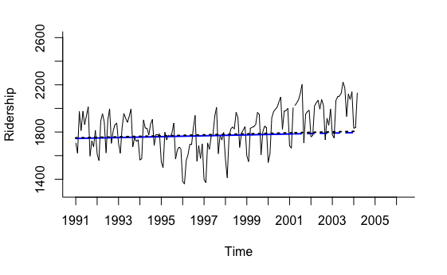

```r
lines(train.lm.linear.trend.pred$mean, lwd = 2, col = "black", lty = 3)
lines(valid.ts)
```

Now, fit a quadratic trend

```r
#fit quadratic trend using function I(), which treats an object "as is".
train.lm.poly.trend <- tslm(train.ts ~ trend + I(trend^2))
summary(train.lm.poly.trend)
```

```
Call:
tslm(formula = train.ts ~ trend + I(trend^2))

Residuals:
    Min      1Q  Median      3Q     Max
-344.79 -101.86   40.89   98.54  279.81

Coefficients:
              Estimate Std. Error t value Pr(>|t|)
(Intercept) 1888.88401   40.91521  46.166  < 2e-16 ***
trend         -6.29780    1.52327  -4.134 6.63e-05 ***
I(trend^2)     0.05362    0.01190   4.506 1.55e-05 ***
---
Signif. codes:  0 ‘***’ 0.001 ‘**’ 0.01 ‘*’ 0.05 ‘.’ 0.1 ‘ ’ 1

Residual standard error: 148.8 on 120 degrees of freedom
Multiple R-squared:  0.1499,    Adjusted R-squared:  0.1358
F-statistic: 10.58 on 2 and 120 DF,  p-value: 5.844e-05
```

```r
train.lm.poly.trend.pred <- forecast(train.lm.poly.trend, h = nValid, level = 0)
par(mfrow = c(2,1))
plot(train.lm.poly.trend.pred, ylim = c(1300, 2600),  ylab = "Ridership",
 xlab = "Time", bty = "l", xaxt = "n", xlim = c(1991,2006.25), main = "", flty = 2)
axis(1, at = seq(1991, 2006, 1), labels = format(seq(1991, 2006, 1)))
```

```r
lines(train.lm.poly.trend$fitted, lwd = 2)
lines(valid.ts)
```

```r
plot(train.lm.poly.trend$residuals, ylim = c(-400, 550),  ylab = "Forecast Errors",
 xlab = "Time", bty = "l", xaxt = "n", xlim = c(1991,2006.25), main = "")
axis(1, at = seq(1991, 2006, 1), labels = format(seq(1991, 2006, 1)))
```

[figure not shown]

```r
lines(valid.ts - train.lm.poly.trend.pred$mean, lwd = 1)
```

Now, let us add seasonality Our new file has a column called Season

```r
AmtrakTS.data <- read.csv("AmtrakTS.csv")
AmtrakTS.data
```

| Validation | Month | Ridership..In.Thousands. | t | Season |
| --- | --- | --- | --- | --- |
| Training | 01/1991 | 1708.917 | 1 | Jan |
| Training | 02/1991 | 1620.586 | 2 | Feb |
| Training | 03/1991 | 1972.715 | 3 | Mar |
| Training | 04/1991 | 1811.665 | 4 | Apr |
| Training | 05/1991 | 1974.964 | 5 | May |
| Training | 06/1991 | 1862.356 | 6 | Jun |
| Training | 07/1991 | 1939.860 | 7 | Jul |
| Training | 08/1991 | 2013.264 | 8 | Aug |
| Training | 09/1991 | 1595.657 | 9 | Sep |
| Training | 10/1991 | 1724.924 | 10 | Oct |

[output cut: 149 more lines]

First split the data into training and validation

```r
ridership.ts <- ts(AmtrakTS.data$Ridership,
    start = c(1991, 1), end = c(2004, 3), freq = 12)
nValid <- 36
nTrain <- length(ridership.ts) - nValid
# partition the data
train.ts <- window(ridership.ts, start = c(1991, 1), end = c(1991, nTrain))
valid.ts <- window(ridership.ts, start = c(1991, nTrain + 1),
                   end = c(1991, nTrain + nValid))
```

# include season as a predictor in tslm(). Here it creates 11 dummies

```r
train.lm.season <- tslm(train.ts ~ season)
summary(train.lm.season)
```

```
Call:
tslm(formula = train.ts ~ season)

Residuals:
     Min       1Q   Median       3Q      Max
-276.165  -52.934    5.868   54.544  215.081

Coefficients:
            Estimate Std. Error t value Pr(>|t|)
(Intercept)  1573.97      30.58  51.475  < 2e-16 ***
season2       -42.93      43.24  -0.993   0.3230
season3       260.77      43.24   6.030 2.19e-08 ***
season4       245.09      44.31   5.531 2.14e-07 ***
season5       278.22      44.31   6.279 6.81e-09 ***
season6       233.46      44.31   5.269 6.82e-07 ***
season7       345.33      44.31   7.793 3.79e-12 ***
season8       396.66      44.31   8.952 9.19e-15 ***
season9        75.76      44.31   1.710   0.0901 .
season10      200.61      44.31   4.527 1.51e-05 ***
season11      192.36      44.31   4.341 3.14e-05 ***
season12      230.42      44.31   5.200 9.18e-07 ***
---
Signif. codes:  0 ‘***’ 0.001 ‘**’ 0.01 ‘*’ 0.05 ‘.’ 0.1 ‘ ’ 1

Residual standard error: 101.4 on 111 degrees of freedom
Multiple R-squared:  0.6348,    Adjusted R-squared:  0.5986
F-statistic: 17.54 on 11 and 111 DF,  p-value: < 2.2e-16
```

Now add trend to the season data

```r
train.lm.trend.season <- tslm(train.ts ~ trend + I(trend^2) + season)
summary(train.lm.trend.season)
```

```
Call:
tslm(formula = train.ts ~ trend + I(trend^2) + season)

Residuals:
     Min       1Q   Median       3Q      Max
-213.775  -39.363    9.711   42.422  152.187

Coefficients:
              Estimate Std. Error t value Pr(>|t|)
(Intercept)  1.697e+03  2.768e+01  61.318  < 2e-16 ***
trend       -7.156e+00  7.293e-01  -9.812  < 2e-16 ***
I(trend^2)   6.074e-02  5.698e-03  10.660  < 2e-16 ***
season2     -4.325e+01  3.024e+01  -1.430  0.15556
season3      2.600e+02  3.024e+01   8.598 6.60e-14 ***
season4      2.606e+02  3.102e+01   8.401 1.83e-13 ***
season5      2.938e+02  3.102e+01   9.471 6.89e-16 ***
season6      2.490e+02  3.102e+01   8.026 1.26e-12 ***
season7      3.606e+02  3.102e+01  11.626  < 2e-16 ***
season8      4.117e+02  3.102e+01  13.270  < 2e-16 ***
season9      9.032e+01  3.102e+01   2.911  0.00437 **
season10     2.146e+02  3.102e+01   6.917 3.29e-10 ***
season11     2.057e+02  3.103e+01   6.629 1.34e-09 ***
season12     2.429e+02  3.103e+01   7.829 3.44e-12 ***
---
Signif. codes:  0 ‘***’ 0.001 ‘**’ 0.01 ‘*’ 0.05 ‘.’ 0.1 ‘ ’ 1

Residual standard error: 70.92 on 109 degrees of freedom
Multiple R-squared:  0.8246,    Adjusted R-squared:  0.8037
F-statistic: 39.42 on 13 and 109 DF,  p-value: < 2.2e-16
```

```r
train.lm.trend.season.pred <- forecast(train.lm.trend.season, h = nValid, level = 0)
par(mfrow = c(2,1))
plot(train.lm.trend.season.pred, ylim = c(1300, 2600),  ylab = "Ridership",
 xlab = "Time", bty = "l", xaxt = "n", xlim = c(1991,2006.25), main = "", flty = 2)
axis(1, at = seq(1991, 2006, 1), labels = format(seq(1991, 2006, 1)))
```

```r
lines(train.lm.trend.season$fitted, lwd = 2)
lines(valid.ts)
```

```r
plot(train.lm.trend.season$residuals, ylim = c(-400, 550),  ylab = "Forecast Errors",
 xlab = "Time", bty = "l", xaxt = "n", xlim = c(1991,2006.25), main = "")
axis(1, at = seq(1991, 2006, 1), labels = format(seq(1991, 2006, 1)))
```

[figure not shown]

```r
lines(valid.ts - train.lm.trend.season.pred$mean, lwd = 1, col="red")
```

Now let’s calculate the autocorrelation

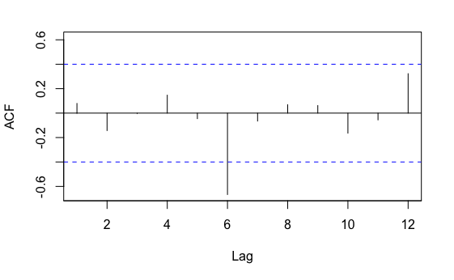

```r
ridership.24.ts <- window(train.ts, start = c(1991, 1), end = c(1991, 24))
Acf(ridership.24.ts, lag.max = 12, main = "")
```

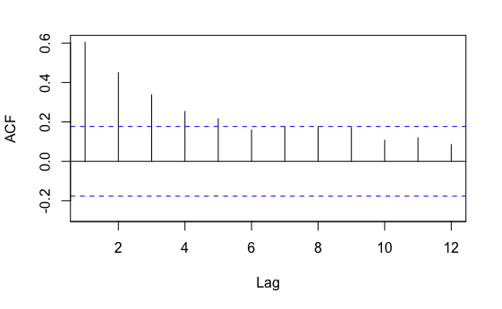

```r
# We can also look at the autocorrelation of the residuals
# For example, we calculate the autocorrelation of the residuals after fitting for season and trend
Acf(train.lm.trend.season$residuals, lag.max = 12, main="")
```

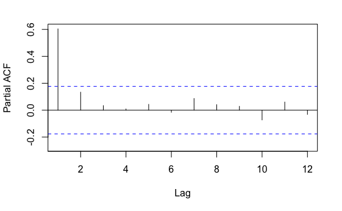

```r
#Let us also display partial autocorrelation
Pacf(train.lm.trend.season$residuals, lag.max = 12, main="")
```

```r
# fit linear regression with quadratic trend and seasonality to Ridership
train.lm.trend.season <- tslm(train.ts ~ trend + I(trend^2) + season)
# fit AR(1) model to training residuals
# use Arima() in the forecast package to fit an ARIMA model # (that includes AR models); order = c(1,0,0) gives an AR(1).
train.res.arima <- Arima(train.lm.trend.season$residuals, order = c(1,0,0))
valid.res.arima.pred <- forecast(train.res.arima, h = 1)
#Output >
summary(train.res.arima)
```

```
Series: train.lm.trend.season$residuals
ARIMA(1,0,0) with non-zero mean

Coefficients:
         ar1     mean
      0.5998   0.3728
s.e.  0.0712  11.8408

sigma^2 estimated as 2876:  log likelihood=-663.54
AIC=1333.08   AICc=1333.29   BIC=1341.52

Training set error measures:
                     ME     RMSE     MAE      MPE     MAPE      MASE
Training set -0.1223159 53.19141 39.8277 103.3885 175.2219 0.5721356
                    ACF1
Training set -0.07509305
```

Thus, our AR(1) model is Et = 0.3728 + 0.5998 * E(t-1) + epsilon

To now forecast residual for April 2001, we plug in the residual from the most recent residual from March 2001 (12.108) into the AR(1) model, this gives

0.3728 + 0.5998 * (12.108 - 0.3728)**

The answer is 7.411. We can get this directly using the forecast() function

** Note: The intercept in the Coefficients table resulting from function Arima() is not exactly an intercept—it is the estimated mean of the series. Hence, to get a forecast, we must subtract this coefficient from our value. In this case, we have Ft + 1 = intercept + slope (yt − intercept).

```r
valid.res.arima.pred
```

```
         Point Forecast     Lo 80   Hi 80     Lo 95    Hi 95
Apr 2001        7.41111 -61.31748 76.1397 -97.70019 112.5224
```

From the plot of the actual vs. forecasted residual series (below), we can see that the AR(1) model fits the residual series quite well. Note, however, that the plot is based on the training data (until March 2001). To evaluate predictive performance of the two-level model [regression + AR(1)], we would have to examine performance (e.g., via MAPE or RMSE metrics) on the validation data, in a fashion similar to the calculation that we performed for April 2001.

```r
plot(train.lm.trend.season$residuals, ylim = c(-250, 250), ylab = "Residuals",
     xlab = "Time", bty = "l", xaxt = "n", xlim = c(1991,2006.25), main = "")
axis(1, at = seq(1991, 2006, 1), labels = format(seq(1991, 2006, 1)))
```

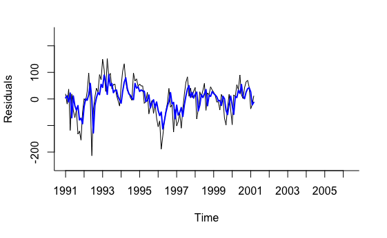

```r
lines(train.res.arima$fitted, lwd = 2, col = "blue")
```

Now, let us consider data-driven methods. Specifically, smoothing methods.

Let us look at moving averages

How should w be chosen for a seasonal series?

```r
Amtrak.data <- read.csv("Amtrak.csv")
Amtrak.data
```

| Ridership..In.Thousands. | Month |
| --- | --- |
| 1708.917 | 01/1991 |
| 1620.586 | 02/1991 |
| 1972.715 | 03/1991 |
| 1811.665 | 04/1991 |
| 1974.964 | 05/1991 |
| 1862.356 | 06/1991 |
| 1939.860 | 07/1991 |
| 2013.264 | 08/1991 |
| 1595.657 | 09/1991 |
| 1724.924 | 10/1991 |

[output cut: 149 more lines]

```r
ridership.ts <- ts(Amtrak.data$Ridership,
    start = c(1991, 1), end = c(2004, 3), freq = 12)
```

```r
library(zoo)
# centered moving average with window order = 12
ma.centered <- ma(ridership.ts, order = 12)
# generate a plot
plot(ridership.ts, ylim = c(1300, 2200),  ylab = "Ridership",
    xlab = "Time", bty = "l", xaxt = "n",
    xlim = c(1991,2004.25), main = "")
axis(1, at = seq(1991, 2004.25, 1), labels = format(seq(1991, 2004.25, 1)))
```

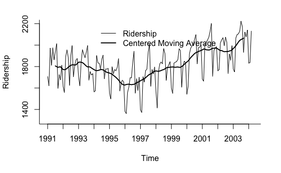

```r
lines(ma.centered, lwd = 2)
legend(1994,2200, c("Ridership","Centered Moving Average"),
    lty=c(1,1), lwd=c(1,2), bty = "n")
```

Now, let’s plot a trailing moving average

```r
# centered moving average with window order = 12
ma.centered <- ma(ridership.ts, order = 12)
# trailing moving average with window k = 12
# in rollmean(), use argument align = right to calculate a trailing moving average.
ma.trailing <- rollmean(ridership.ts, k = 12, align = "right")
# generate a plot
plot(ridership.ts, ylim = c(1300, 2200),  ylab = "Ridership",
    xlab = "Time", bty = "l", xaxt = "n",
    xlim = c(1991,2004.25), main = "")
axis(1, at = seq(1991, 2004.25, 1), labels = format(seq(1991, 2004.25, 1)))
```

```r
lines(ma.centered, lwd = 2)
lines(ma.trailing, lwd = 2, lty = 2)
```

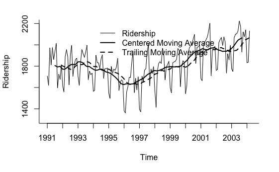

```r
legend(1994,2200, c("Ridership","Centered Moving Average", "Trailing Moving Average"),
    lty=c(1,1,2), lwd=c(1,2,2), bty = "n")
```

Next, we illustrate a 12-month moving average forecaster for the Amtrak ridership. We partition the Amtrak ridership time series, leaving the last 36 months as the validation period. Applying a moving average forecaster with window w = 12. Note that for the first 12 records of the training period, there is no forecast (because there are less than 12 past values to average). Also, note that the forecasts for all months in the validation period are identical (1938.481) because the method assumes that information is known only until March 2001.

```r
# partition the data
nValid <- 36
nTrain <- length(ridership.ts) - nValid
train.ts <- window(ridership.ts, start = c(1991, 1), end = c(1991, nTrain))
valid.ts <- window(ridership.ts, start = c(1991, nTrain + 1),
    end = c(1991, nTrain + nValid))
# moving average on training
ma.trailing <- rollmean(train.ts, k = 12, align = "right")
# obtain the last moving average in the training period
last.ma <- tail(ma.trailing, 1)
# create forecast based on last MA
ma.trailing.pred <- ts(rep(last.ma, nValid), start = c(1991, nTrain + 1),
    end = c(1991, nTrain + nValid), freq = 12)

# plot the series
plot(train.ts, ylim = c(1300, 2600),  ylab = "Ridership", xlab = "Time", bty = "l",
    xaxt = "n", xlim = c(1991,2006.25), main = "")
axis(1, at = seq(1991, 2006, 1), labels = format(seq(1991, 2006, 1)))
```

```r
lines(ma.trailing, lwd = 2, col = "blue")
lines(ma.trailing.pred, lwd = 2, col = "blue", lty = 2)
```

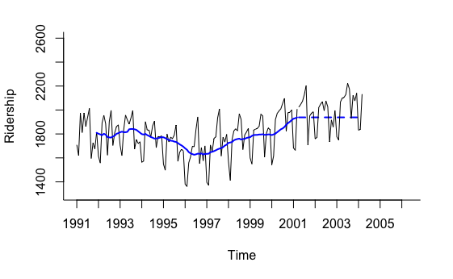

```r
lines(valid.ts)
```

```r
AmtrakTS.data <- read.csv("AmtrakTS.csv")
AmtrakTS.data
```

| Validation | Month | Ridership..In.Thousands. | t | Season |
| --- | --- | --- | --- | --- |
| Training | 01/1991 | 1708.917 | 1 | Jan |
| Training | 02/1991 | 1620.586 | 2 | Feb |
| Training | 03/1991 | 1972.715 | 3 | Mar |
| Training | 04/1991 | 1811.665 | 4 | Apr |
| Training | 05/1991 | 1974.964 | 5 | May |
| Training | 06/1991 | 1862.356 | 6 | Jun |
| Training | 07/1991 | 1939.860 | 7 | Jul |
| Training | 08/1991 | 2013.264 | 8 | Aug |
| Training | 09/1991 | 1595.657 | 9 | Sep |
| Training | 10/1991 | 1724.924 | 10 | Oct |

[output cut: 149 more lines]

```r
ridership.ts <- ts(AmtrakTS.data$Ridership,
    start = c(1991, 1), end = c(2004, 3), freq = 12)
nValid <- 36
nTrain <- length(ridership.ts) - nValid
# partition the data
train.ts <- window(ridership.ts, start = c(1991, 1), end = c(1991, nTrain))
valid.ts <- window(ridership.ts, start = c(1991, nTrain + 1),
                   end = c(1991, nTrain + nValid))
# fit regression model with trend and seasonality
train.lm.trend.season <- tslm(train.ts ~ trend + I(trend^2) + season)
# create single-point forecast
train.lm.trend.season.pred <- forecast(train.lm.trend.season, h = 1, level = 0)
# apply MA to residuals
ma.trailing <- rollmean(train.lm.trend.season$residuals, k = 12, align = "right")
last.ma <- tail(ma.trailing, 1)
train.lm.trend.season.pred
```

```
         Point Forecast     Lo 0     Hi 0
Apr 2001       2004.271 2004.271 2004.271
```

```r
last.ma
```

```
          Mar
2001 30.78068
```

Now, let’s apply exponential smoothing to the residuals from our previous model. The residuals are assumed to have no trend or seasonality

```r
# get residuals
residuals.ts <- train.lm.trend.season$residuals
# run simple exponential smoothing
# use ets() with model = "ANN" (additive error (A), no trend (N), no seasonality (N))
# and alpha = 0.2 to fit simple exponential smoothing.
ses <- ets(residuals.ts, model = "ANN", alpha = 0.2)
ses.pred <- forecast(ses, h = nValid, level = 0)
plot(ses.pred, ylim = c(-250, 300),  ylab = "Ridership", xlab = "Time",
     bty = "l", xaxt = "n", xlim = c(1991,2006.25), main = "", flty = 2)
lines(train.lm.trend.season.pred$fitted, lwd = 2, col = "blue")
```

```r
axis(1, at = seq(1991, 2006, 1), labels = format(seq(1991, 2006, 1)))
lines(ses.pred$fitted, lwd = 2, col = "blue")
```

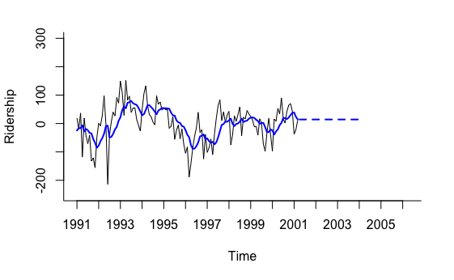

```r
lines(valid.ts)
```

Now, let us fit the Holt-Winters exponential model

```r
# run Holt-Winters exponential smoothing
# use ets() with option model = "MAA" to fit Holt-Winter's exponential smoothing
# with multiplicative error, additive trend, and additive seasonality.
hwin <- ets(train.ts, model = "MAA")
# create predictions
hwin.pred <- forecast(hwin, h = nValid, level = 0)
# plot the series
plot(hwin.pred, ylim = c(1300, 2600),  ylab = "Ridership", xlab = "Time",
    bty = "l", xaxt = "n", xlim = c(1991,2006.25), main = "", flty = 2)
axis(1, at = seq(1991, 2006, 1), labels = format(seq(1991, 2006, 1)))
```

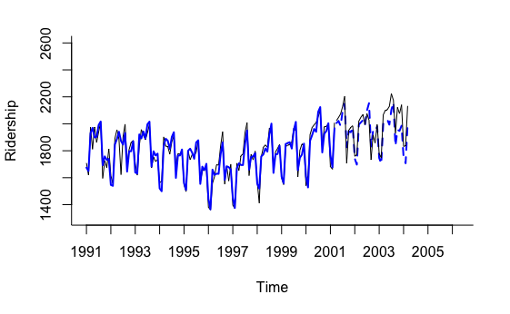

```r
lines(hwin.pred$fitted, lwd = 2, col = "blue")
lines(valid.ts)
```

```r
hwin
```

```
ETS(M,A,A)

Call:
 ets(y = train.ts, model = "MAA")

  Smoothing parameters:
    alpha = 0.5483
    beta  = 1e-04
    gamma = 1e-04

  Initial states:
    l = 1881.6423
    b = 0.4164
    s=27.1143 -10.6847 -2.9465 -121.1763 201.1625 147.3359
           37.6688 75.8711 60.4021 44.4779 -252.047 -207.1783

  sigma:  0.0317

     AIC     AICc      BIC
1616.219 1622.048 1664.027
```